# Sports Retail Analysis

This project demonstrates how to combine multiple data sources (Brands, Finance, Product Info, Reviews, and Traffic) into a unified dataset, perform data cleaning and exploratory analysis in SQL, and build interactive dashboards in Power BI to derive business insights. The project uses a dataset from Kaggle, which contains data scraped from an online sports retail store like product name, description, brand, listing price, sale price, rating, and number of reviews.

Originally I had done this in Microsoft SQL Server, but Kaggle does not support it so I will instead show the MS SQL Server code and a preview of the query results only. However, the SQL database is available on SSMS or Azure Data Studio and you can run the SQL file yourself which can be downloaded in the github repository.

## How to Connect to the Database

You can connect to the Azure SQL database using the following details:

- **Server:** `tcp:onlinesportsretail.database.windows.net,1433`
- **Database:** `Sports Retail Revenue`
- **Username:** `demo_user`
- **Password:** `ZsTBAjAD3(h1I`
- **Authentication:** SQL Server Authentication

### How to Connect:

1. Open Azure Data Studio or SSMS.
2. Use the connection details above.
3. Run the sample queries provided in the `/SQL` folder.

# Data Transformations and Cleaning with SQL

There were 5 tables in this dataset:

- Brands – Contains product IDs and brand information (Adidas, Nike).
- Finance – Lists listing price, sale price, discount, and total revenue.
- Product Info – Includes product name, description, etc.
- Reviews – Stores rating (out of 5) and number of reviews for each product.
- Traffic – Contains timestamps (last_visited) or other engagement metrics.

For convenience I combined them all into 1 table called combined_data

```python
-- JOINING ALL TABLES
SELECT
    b.product_id,
	p.product_name,
    p.description,
    b.brand,
    f.listing_price,
	f.sale_price,
    f.discount,
	f.revenue,
    r.rating,
    r.reviews,
    t.last_visited
INTO dbo.combined_data
FROM dbo.brands b
JOIN dbo.finance f ON b.product_id = f.product_id
JOIN dbo.product_info p ON b.product_id = p.product_id
JOIN dbo.reviews r ON b.product_id = r.product_id
JOIN dbo.traffic t ON b.product_id = t.product_id;
```

I created a staging table before modifying the data so as to not disturb the original data. Here is a preview of the staging table

| **product_id** | **product_name** | **description** | **brand** | **listing_price** | **sale_price** | **discount** | **revenue** | **rating** | **reviews** | **last_visited** |
| --- | --- | --- | --- | --- | --- | --- | --- | --- | --- | --- |
| 130690-017 | Air Jordan 12 Retro | An all-time favourite among players and sneakerheads, the Air Jordan 12 Retro features full-length Zoom Air cushioning and full-grain leather styled with distinct radial stitch lines. | Nike | 0 | 159.949996948242 | 0 | 6909.83984375 | 4.5 | 24 | 2019-07-29 21:21:00.0000000 |
| 133000-106 | Air Jordan OG | First released in '98, the Air Jordan OG was designed for the women's basketball community who wanted an AJ all of their own. The original Air Jordan for women has dimpled leather and midsole sculptin… | Nike | 0 | 119.949996948242 | 0 | 0 | 0 | 0 | 2018-08-21 01:30:00.0000000 |
| 280648 | Men's Originals Summer Adilette Slippers | From 72' until now, these adidas Originals Sandals have been a favorite pick amongst the crowd. Quick drying functionality makes it a perfect outdoor as well as an indoor footwear. Distinct designing … | Adidas | 29.9899997711182 | 29.9899997711182 | 0 | 2915.03002929688 | 4.19999980926514 | 54 | 2019-05-01 00:39:00.0000000 |
| 288022 | Men's Originals Summer Adilette Slides | The adidas Originals Adilette slip ons for men. The Rubber sole keeps your feet in supreme comfort and it comes with 3-Stripes on the upper Synthetic bandage. | Adidas | 29.9899997711182 | 29.9899997711182 | 0 | 5128.2900390625 | 3.29999995231628 | 95 | 2019-10-02 11:04:00.0000000 |
| 310805-137 | Air Jordan 10 Retro | Featuring soft, lightweight cushioning, the Air Jordan 10 Retro offers performance-inspired comfort with iconic Air Jordan detailing. | Nike | 0 | 159.949996948242 | 0 | 64203.9296875 | 4.69999980926514 | 223 | 2019-07-25 17:17:00.0000000 |
| 313358-006 | Air Jordan 7 Retro | The Air Jordan 7 Retro celebrates MJ's championship legacy with a reissue of his 7th game shoe, the one he famously wore to gold-medal glory. | Nike | 159.949996948242 | 111.970001220703 | 0 | 806.179992675781 | 4.80000019073486 | 4 | 2018-10-06 14:02:00.0000000 |
| 315115-112 | Nike Air Force 1 '07 | The radiance lives on in the Nike Air Force 1 '07, the b-ball OG that puts a fresh spin on what you know best: crisp leather in an all-white colourway for a statement look on and off the court. | Nike | 0 | 74.9499969482422 | 0 | 9038.9697265625 | 4.5 | 67 | 2020-02-01 00:48:00.0000000 |
| 315122-001 | Nike Air Force 1 '07 | Hoops in the park, Sunday BBQs and sunshine. The radiance lives on in the Nike Air Force 1 '07, the b-ball OG that puts a fresh spin on what you know best: crisp leather in an all-black colourway for … | Nike | 0 | 72.9499969482422 | 0 | 10242.1796875 | 4.5 | 78 | 2020-03-06 01:08:00.0000000 |
| 315123-111 | Nike Air Force 1 Mid '07 | The legend lives on in the Nike Air Force 1 Mid '07 Men's Shoe, a modern take on the icon that blends classic style and fresh, crisp details. | Nike | 0 | 75.9499969482422 | 0 | 1777.22998046875 | 4.5 | 13 | 2018-10-11 16:29:00.0000000 |
| 325213-139 | Nike Air Max 90 | The Nike Air Max 90 Women's Shoe honours its roots with a supportive upper and the excellent cushioning that made the original a favourite. | Nike | 94.9499969482422 | 75.9700012207031 | 0 | 683.72998046875 | 3.59999990463257 | 5 | 2018-07-28 15:17:00.0000000 |
| 343880-090 | Nike Benassi | The Nike Benassi Slide features a lined upper with a bold logo for plush comfort and an athletic look. A foam midsole and outsole provide lightweight impact protection. | Nike | 0 | 24.9500007629395 | 0 | 1482.03002929688 | 4.09999990463257 | 33 | 2019-01-24 16:35:00.0000000 |
| 343881-412 | Nike Benassi | The Nike Benassi Women's Slide features a lined upper with a bold logo for plush comfort and an athletic look. A foam midsole and outsole provide lightweight impact protection. | Nike | 0 | 24.9500007629395 | 0 | 538.919982910156 | 4.30000019073486 | 12 | 2019-05-04 10:17:00.0000000 |
| 366731-100 | Nike Air Force 1 Mid '07 | The legend lives on in the Nike Air Force 1 Mid '07 Women's Shoe, a modern take on the icon that blends classic style and fresh, crisp details. | Nike | 78.9499969482422 | 63.1699981689453 | 0 | 454.820007324219 | 3.79999995231628 | 4 | 2019-12-01 12:49:00.0000000 |
| 414571-030 | Air Jordan 13 Retro | Featuring a panther-inspired design that takes after Michael Jordan's on-court presence, the Air Jordan 13 Retro is based on the OG model and has the same responsive cushioning and premium materials t… | Nike | 0 | 159.949996948242 | 0 | 9788.9404296875 | 3.90000009536743 | 34 | 2019-01-13 22:31:00.0000000 |
| 415445-102 | Nike Air Monarch IV | The Nike Air Monarch IV Lifestyle/Gym Shoe delivers lightweight cushioning and durable support with a Phylon midsole and a leather upper. Flex grooves provide natural flexibility with every step. | Nike | 0 | 52.9500007629395 | 0 | 8959.1396484375 | 4.09999990463257 | 94 | 2018-05-10 19:14:00.0000000 |
| 487471-003 | Air Jordan 14 Retro | The Air Jordan 14 Retro has class, comfort and the singular look of the original, with heritage-inspired colours, full-grain leather and responsive Zoom Air cushioning. | Nike | 179.949996948242 | 143.970001220703 | 0 | 3109.75 | 4.19999980926514 | 12 | 2019-01-31 23:42:00.0000000 |

```python
SELECT *
INTO combined_staging
FROM combined_data;
```

## 1. Removing duplicates

The first step in my data cleaning process is removing any duplicate rows. This was easy as there is a unique identifier, product_id.

```python
DELETE T
FROM
(
SELECT *,
DupRank = ROW_NUMBER() OVER (
			  PARTITION BY product_id
			  ORDER BY product_name
			)
FROM combined_staging
) AS T
WHERE DupRank > 1;
```

## 2. Standardizing data

Next I standardized data by trimming leading and trailing whitespace. I noticed there was whitespace in the product_name and description columns.

```python
UPDATE combined_data
SET product_name = TRIM(product_name),
description = TRIM(description);
```

Some of the rows have the gender in proper case, some in all caps, and some are a mix. I will standardize them all to proper case to be able to segment the clothes/footwear by gender easily

```python
SELECT product_id, product_name, brand
FROM combined_staging
WHERE product_name LIKE '%men''s%';
```

| **product_id** | **product_name** | **brand** |
| --- | --- | --- |
| 280648 | Men's Originals Summer Adilette Slippers | Adidas |
| 288022 | Men's Originals Summer Adilette Slides | Adidas |
| AC7042 | men's ADIDAS ORIGINALS PW HU HOLI STAN SMITH SHOES | Adidas |
| AC7043 | men's ADIDAS ORIGINALS PW HU HOLI STAN SMITH SHOES | Adidas |
| AC7104 | WOMEN'S ADIDAS RUNNING EDGEBOUNCE SHOES | Adidas |
| AC7556 | WOMEN'S ADIDAS BY STELLA MCCARTNEY PUREBOOST X TRAINING 3.0 SHOES | Adidas |
| AC7943 | WOMEN'S ADIDAS OUTDOOR TERREX TRACEROCKER SHOES | Adidas |
| AC8122 | Men's adidas Running Edge PR Shoes | Adidas |
| AC8133 | MEN'S ADIDAS RUNNING SOLAR DRIVE SHOES | Adidas |
| AC8765 | Women's adidas originals ARKYN SHOES | Adidas |
| AQ0863 | Men's adidas Originals Swift Run Shoes | Adidas |
| AQ0886 | WOMEN'S ADIDAS ORIGINALS TUBULAR SHADOW CK SHOES | Adidas |
| AQ0907 | MEN'S ADIDAS ORIGINALS FUTUREPACER SHOES | Adidas |
| AQ6095 | Women's adidas Vengeful Boost Running Shoes | Adidas |
| B42099 | MEN'S ADIDAS SPORTS INSPIRED HOOPS 2.0 MID SHOES | Adidas |
| B42122 | WOMEN'S ADIDAS SWIM ADILETTE COMFORT SLIDES | Adidas |
| B42259 | MEN'S ADIDAS ORIGINALS 3ST.003 SHOES | Adidas |
| B42314 | Women's adidas Sport Inspired VL Court 2.0 Shoes | Adidas |
| B42315 | Women's adidas Sport Inspired VL Court 2.0 Shoes | Adidas |
| B43600 | WOMEN'S ADIDAS SWIM CLOUDFOAM FLIP FLOPS | Adidas |
| B43601 | WOMEN'S ADIDAS SWIM CLOUDFOAM FLIP FLOPS | Adidas |
| B43642 | Men's adidas Sport Inspired Cloudfoam Racer TR Shoes | Adidas |
| B43651 | Men's adidas Sport Inspired Cloudfoam Racer TR Shoes | Adidas |
| B43659 | MEN'S ADIDAS SPORT INSPIRED CLOUDFOAM ADVANTAGE SHOES | Adidas |
| B43665 | MEN'S ADIDAS SPORT INSPIRED EASY VULC 2.0 SHOES | Adidas |
| B43687 | Men's adidas Running Galaxy Trail Shoes | Adidas |
| B43732 | MEN'S ADIDAS SPORT INSPIRED LITE RACER SHOES | Adidas |
| B43739 | Men's adidas Sport Inspired VS Advantage Shoes | Adidas |
| B43742 | MEN'S ADIDAS SPORT INSPIRED CAFLAIRE SHOES | Adidas |
| B43743 | MEN'S ADIDAS SPORT INSPIRED CAFLAIRE SHOES | Adidas |

```python
-- Ensuring the "Men's" or "Women's" part of the product name is in same format (first letter capitalized + rest not capitalized)
UPDATE combined_staging
SET product_name = REPLACE(product_name COLLATE Latin1_General_CI_AS, 'women''s', 'Women''s')
WHERE product_name COLLATE Latin1_General_CI_AS LIKE 'women''s%';

UPDATE combined_staging
SET product_name = REPLACE(product_name COLLATE Latin1_General_CI_AS, 'men''s', 'Men''s')
WHERE product_name COLLATE Latin1_General_CI_AS LIKE 'men''s%';
```

Ensuring there aren't any typos in the 2 brands we expect (Adidas & Nike)

```python
SELECT COUNT(DISTINCT brand) as Num_of_brands
FROM combined_staging;
```

| **Num_of_brands** |
| --- |
| 2 |

listing_price, sale_price, discount, and revenue are currency so they should be Decimals

```python
ALTER TABLE combined_staging
ALTER COLUMN listing_price DECIMAL(10, 2);

ALTER TABLE combined_staging
ALTER COLUMN sale_price DECIMAL(10, 2);

ALTER TABLE combined_staging
ALTER COLUMN discount DECIMAL(10, 2);

ALTER TABLE combined_staging
ALTER COLUMN revenue DECIMAL(10, 2);
```

```python
SELECT TOP 20 product_id, product_name, brand, rating, reviews
FROM combined_staging;
```

| **product_id** | **product_name** | **brand** | **rating** | **reviews** |
| --- | --- | --- | --- | --- |
| 130690-017 | Air Jordan 12 Retro | Nike | 4.5 | 24 |
| 133000-106 | Air Jordan OG | Nike | 0 | 0 |
| 280648 | Men's Originals Summer Adilette Slippers | Adidas | 4.19999980926514 | 54 |
| 288022 | Men's Originals Summer Adilette Slides | Adidas | 3.29999995231628 | 95 |
| 310805-137 | Air Jordan 10 Retro | Nike | 4.69999980926514 | 223 |
| 313358-006 | Air Jordan 7 Retro | Nike | 4.80000019073486 | 4 |
| 315115-112 | Nike Air Force 1 '07 | Nike | 4.5 | 67 |
| 315122-001 | Nike Air Force 1 '07 | Nike | 4.5 | 78 |
| 315123-111 | Nike Air Force 1 Mid '07 | Nike | 4.5 | 13 |
| 325213-139 | Nike Air Max 90 | Nike | 3.59999990463257 | 5 |
| 343880-090 | Nike Benassi | Nike | 4.09999990463257 | 33 |
| 343881-412 | Nike Benassi | Nike | 4.30000019073486 | 12 |
| 366731-100 | Nike Air Force 1 Mid '07 | Nike | 3.79999995231628 | 4 |
| 414571-030 | Air Jordan 13 Retro | Nike | 3.90000009536743 | 34 |
| 415445-102 | Nike Air Monarch IV | Nike | 4.09999990463257 | 94 |
| 487471-003 | Air Jordan 14 Retro | Nike | 4.19999980926514 | 12 |
| 487754-303 | Nike Air Tailwind 79 | Nike | 3.90000009536743 | 17 |
| 488161-602 | Nike Solarsoft | Nike | 3.79999995231628 | 5 |
| 528895-003 | Air Jordan 11 Retro Low | Nike | 4.40000009536743 | 25 |
| 553558-125 | Air Jordan 1 Low | Nike | 4.59999990463257 | 34 |

We want rating to have 1 decimal place

```python
ALTER TABLE combined_staging
ALTER COLUMN rating DECIMAL(10, 1);
```

Want reviews to be an integer

```python
ALTER TABLE combined_staging
ALTER COLUMN reviews INT;
```

## 3. Filter out null/blank rows

```python
DELETE
FROM combined_staging
WHERE ((product_name IS NULL OR product_name = '') AND (description IS NULL OR description = '')) OR (brand IS NULL or brand = '')
AND listing_price IS NULL AND sale_price IS NULL AND discount IS NULL AND revenue IS NULL;
```

I want to filter out rows that are missing important information like product_name, description or brand or all finance info

# Initial Exploratory Analysis

```python
SELECT TOP 20 product_id, product_name, brand, revenue, rating, reviews, last_visited
FROM combined_staging
WHERE ((rating = 0 AND reviews != 0) or (reviews = 0 and rating != 0));
```

| **product_id** | **product_name** | **brand** | **revenue** | **rating** | **reviews** | **last_visited** |
| --- | --- | --- | --- | --- | --- | --- |
| AC7045 | Men's ADIDAS ORIGINALS PW HU HOLI STAN SMITH SHOES | Adidas | 4229.15 | 0.0 | 47 | 2018-08-08 11:59:00.0000000 |
| AH2156 | Women's ADIDAS TENNIS ADIZERO CLUB 2.0 SHOES | Adidas | 0.00 | 2.7 | 0 | 2019-10-31 22:07:00.0000000 |
| AQ1134 | Women's ADIDAS ORIGINALS SAMBAROSE SHOES | Adidas | 0.00 | 3.6 | 0 | NULL |
| B22705 | UNISEX ADIDAS ORIGINALS SKATEBOARDING 3MC SHOES | Adidas | 1684.33 | 0.0 | 26 | 2019-12-25 06:56:00.0000000 |
| B22790 | Men's ADIDAS ORIGINALS SKATEBOARDING MATCHCOURT SHOES | Adidas | 2065.66 | 0.0 | 41 | NULL |
| B37361 | Women's ADIDAS ORIGINALS STAN SMITH NEW BOLD SHOES | Adidas | 323.93 | 0.0 | 4 | 2019-02-08 18:40:00.0000000 |
| B41648 | Men's ADIDAS ORIGINALS GAZELLE SHOES | Adidas | 0.00 | 2.0 | 0 | 2019-08-14 09:58:00.0000000 |
| B44697 | Women's ADIDAS ORIGINALS SAMBA OG SHOES | Adidas | 6118.47 | 0.0 | 85 | 2018-10-27 01:09:00.0000000 |
| B96578 | Men's ADIDAS RUNNING DURAMO 9 SHOES | Adidas | 7882.69 | 0.0 | 73 | 2018-07-11 09:51:00.0000000 |
| BD7439 | Men's adidas Originals Stan Smith Shoes | Adidas | 791.80 | 0.0 | 11 | 2018-11-05 14:15:00.0000000 |
| BD7480 | Men's adidas Originals Gazelle Shoes | Adidas | 2936.99 | 0.0 | 34 | 2019-02-03 09:38:00.0000000 |
| CG4050 | Women's adidas Sport Inspired Duramo Lite 2.0 Shoes | Adidas | 1597.73 | 0.0 | 37 | 2020-01-17 10:34:00.0000000 |
| CG6025 | Women's adidas Originals I-5923 Shoes | Adidas | 9178.47 | 0.0 | 85 | 2018-10-03 18:53:00.0000000 |
| CG6222 | Women's adidas Originals Arkyn Shoes | Adidas | 6910.85 | 0.0 | 64 | NULL |
| CI1823 | Men's adidas RUNNING YAMO 1.0 SHOES | Adidas | 3713.65 | 0.0 | 86 | 2019-07-28 21:39:00.0000000 |
| CI1935 | Men's adidas RUNNING toril SHOES | Adidas | 0.00 | 1.0 | 0 | 2020-03-23 01:18:00.0000000 |
| CI2606 | Women's adidas SWIM BRIZO 4.0 Slippers | Adidas | 0.00 | 2.9 | 0 | 2018-07-25 16:11:00.0000000 |
| CI9718 | Men's ADIDAS RUNNING ZETA 1.0 SHOES | Adidas | 0.00 | 3.0 | 0 | 2018-12-16 09:51:00.0000000 |
| CI9916 | Men's ADIDAS RUNNING NAYO 1.0 SHOES | Adidas | 3778.49 | 0.0 | 84 | 2020-02-03 06:47:00.0000000 |
| CJ8012 | Men's ADIDAS RUNNING KYLEN 1.0 SHOES | Adidas | 2653.94 | 0.0 | 59 | 2020-02-07 09:32:00.0000000 |

There are rows with one of rating or review is 0 but the other is not. Typically both are required when leaving a review

```python
SELECT *
FROM combined_staging
WHERE ((rating = 0 AND reviews != 0) or (reviews = 0 and rating != 0))
AND brand = 'Nike';
```

| **product_id** | **product_name** | **description** | **brand** | **listing_price** | **sale_price** | **discount** | **revenue** | **rating** | **reviews** | **last_visited** |
| --- | --- | --- | --- | --- | --- | --- | --- | --- | --- | --- |

There are no rows where the brand is Nike. It seems like Adidas allows ppl to leave only one or reviews and ratings might be processed separately for Adidas products, causing temporary mismatches.

Here are some questions I want to probe into using SQL

- How do the price points of Nike and Adidas products differ?
- Is there a difference in the amount of discount offered between the brands?
- Is there any correlation between revenue and reviews? And if so, how strong is it?
- Do Mens or Womens shoe contribute the most to revenue?
- Does the length of a product's description influence a product's rating and reviews?
- Are there any trends or gaps in the volume of reviews by month?
- How much of the company's stock consists of footwear items? What is the median revenue generated by these products?
- How does footwear's median revenue differ from clothing products?

## How do the price points of Nike and Adidas products differ?

Price points for each percentile - 25%, 50%, and 75%

**Step 1**: Create the temporary table

```python
DROP TABLE IF EXISTS #price_points;

SELECT
    brand,
    sale_price,
    PERCENTILE_CONT(0.25) WITHIN GROUP (ORDER BY sale_price) OVER (PARTITION BY brand) AS low,
    PERCENTILE_CONT(0.5) WITHIN GROUP (ORDER BY sale_price) OVER (PARTITION BY brand) AS median,
    PERCENTILE_CONT(0.75) WITHIN GROUP (ORDER BY sale_price) OVER (PARTITION BY brand) AS high
INTO #price_points
FROM combined_staging
WHERE brand IN ('Nike', 'Adidas');
```

**Step 2**: Compare price points between Nike and Adidas

```python
SELECT
    'Low' AS tier,
    MAX(CASE WHEN brand = 'Nike' THEN low END) AS Nike,
    MAX(CASE WHEN brand = 'Adidas' THEN low END) AS Adidas
FROM #price_points

UNION ALL

SELECT
    'Median' AS tier,
    MAX(CASE WHEN brand = 'Nike' THEN median END) AS Nike,
    MAX(CASE WHEN brand = 'Adidas' THEN median END) AS Adidas
FROM #price_points

UNION ALL

SELECT
    'High' AS tier,
    MAX(CASE WHEN brand = 'Nike' THEN high END) AS Nike,
    MAX(CASE WHEN brand = 'Adidas' THEN high END) AS Adidas
FROM #price_points;
```

| **tier** | **Nike** | **Adidas** |
| --- | --- | --- |
| Low | 71.97 | 27.99 |
| Medium | 99.95 | 39.99 |
| High | 127.97 | 64.99 |

Nike's price points are consistently higher for each tier. Now I want to determine exactly how much more higher Nike's prices are

```python
SELECT
    'Low' AS tier,
    '$' + FORMAT(ABS(MAX(CASE WHEN brand = 'Nike' THEN low END)
             - MAX(CASE WHEN brand = 'Adidas' THEN low END)), 'N2') AS abs_difference,
    FORMAT(
        CAST(MAX(CASE WHEN brand = 'Nike' THEN low END) AS FLOAT)
        / MAX(CASE WHEN brand = 'Adidas' THEN low END) * 100, 'N2'
    ) + '%' AS prop_difference
FROM #price_points

UNION ALL

SELECT
    'Median' AS tier,
    '$' + FORMAT(ABS(MAX(CASE WHEN brand = 'Nike' THEN median END)
             - MAX(CASE WHEN brand = 'Adidas' THEN median END)), 'N2') AS abs_difference,
    FORMAT(
        CAST(MAX(CASE WHEN brand = 'Nike' THEN median END) AS FLOAT)
        / MAX(CASE WHEN brand = 'Adidas' THEN median END) * 100, 'N2'
    ) + '%' AS prop_difference
FROM #price_points

UNION ALL

SELECT
    'High' AS tier,
    '$' + FORMAT(ABS(MAX(CASE WHEN brand = 'Nike' THEN high END)
             - MAX(CASE WHEN brand = 'Adidas' THEN high END)), 'N2') AS abs_difference,
    FORMAT(
        CAST(MAX(CASE WHEN brand = 'Nike' THEN high END) AS FLOAT)
        / MAX(CASE WHEN brand = 'Adidas' THEN high END) * 100, 'N2'
    ) + '%' AS prop_difference
FROM #price_points;
```

| **tier** | **abs_difference** | **prop_difference** |
| --- | --- | --- |
| Low | 43.98 | 257.13% |
| Medium | 59.96 | 249.94% |
| High | 62.98 | 196.91% |

**Step 3**: Count products in each tier and calculate the percentage of all items that are in that tier

```python
WITH tier_counts AS (
    SELECT
        brand,
        COUNT(CASE WHEN sale_price <= low THEN 1 END) AS low_count,
        COUNT(CASE WHEN sale_price > low AND sale_price <= medium THEN 1 END) AS medium_count,
        COUNT(CASE WHEN sale_price > medium AND sale_price <= high THEN 1 END) AS high_count,
        COUNT(CASE WHEN sale_price > high THEN 1 END) AS very_high_count,
        COUNT(*) AS total_count
    FROM #price_points
    GROUP BY brand
)
SELECT
    brand,
    low_count,
    FORMAT(CAST(low_count AS FLOAT) / total_count * 100, 'N2') + '%' AS low_percent,
    medium_count,
    FORMAT(CAST(medium_count AS FLOAT) / total_count * 100, 'N2') + '%' AS medium_percent,
    high_count,
    FORMAT(CAST(high_count AS FLOAT) / total_count * 100, 'N2') + '%' AS high_percent,
    very_high_count,
    FORMAT(CAST(very_high_count AS FLOAT) / total_count * 100, 'N2') + '%' AS very_high_percent
FROM tier_counts;
```

| **brand** | **low_count** | **low_percent** | **medium_count** | **medium_percent** | **high_count** | **high_percent** | **very_high_count** | **very_high_percent** |
| --- | --- | --- | --- | --- | --- | --- | --- | --- |
| Nike | 144 | 26.42% | 164 | 30.09% | 103 | 18.90% | 134 | 24.59% |
| Adidas | 712 | 27.65% | 639 | 24.82% | 592 | 22.99% | 632 | 24.54% |

## Is there a difference in the amount of discount offered between the brands?

```python
SELECT brand, FORMAT(AVG(discount)*100, 'N2') + '%' AS discount_avg
FROM combined_staging
WHERE brand IS NOT NULL
GROUP BY brand;
```

| **brand** | **discount_avg** |
| --- | --- |
| Nike | 0.00% |
| Adidas | 33.45% |

## Is there any correlation between revenue and reviews? And if so, how strong is it?

Creating stored procedure to calculate correlation coefficient.

correlation coefficient: r = (((count *) * sum(x*y)) - (sum(x)*sum(y))) / sqrt(((count*)*sum(pow(x,2)) - pow(sum(x), 2)) *(count*)*sum(pow(y,2))- pow(sum(y), 2)))

```python
IF OBJECT_ID(N'dbo.CalculateCorrelation', N'P') IS NOT NULL
    DROP PROCEDURE dbo.CalculateCorrelation;
GO

CREATE PROCEDURE dbo.CalculateCorrelation
    @x_column NVARCHAR(128),
    @y_column NVARCHAR(128)
AS
BEGIN
    DECLARE @sql NVARCHAR(MAX);

    SET @sql = '
        SELECT
            (COUNT(*) * SUM(CAST(' + @x_column + ' AS FLOAT) * CAST(' + @y_column + ' AS FLOAT)) -
             (SUM(CAST(' + @x_column + ' AS FLOAT)) * SUM(CAST(' + @y_column + ' AS FLOAT)))) /
            SQRT(
                (COUNT(*) * SUM(SQUARE(CAST(' + @x_column + ' AS FLOAT))) -
                 SQUARE(SUM(CAST(' + @x_column + ' AS FLOAT)))) *
                (COUNT(*) * SUM(SQUARE(CAST(' + @y_column + ' AS FLOAT))) -
                 SQUARE(SUM(CAST(' + @y_column + ' AS FLOAT))))
            ) AS correlation_coefficient
        FROM combined_staging;
    ';

    EXEC sp_executesql @sql;
END;
GO

EXEC dbo.CalculateCorrelation @x_column = 'revenue', @y_column = 'reviews';
```

| **correlation_coefficient** |
| --- |
| 0.658202728471641 |

A correlation value of 0.65 suggests a moderately strong relationship between revenue and the number of reviews left on a product.

## Is there any correlation between revenue and ratings? And if so, how strong is it?

```python
EXEC dbo.CalculateCorrelation @x_column = 'revenue', @y_column = 'rating';
```

| **correlation_coefficient** |
| --- |
| 0.144905319935389 |

There is a weak relationship between revenue and rating, suggesting rating isn't as important as the number of reviews.

## Do Mens or Womens shoe contribute the most to revenue?

```python
ALTER TABLE combined_staging
ADD gender AS ( CASE
        WHEN description LIKE '%Women''s%' OR product_name LIKE '%Women%' THEN 'Womens'
        WHEN description LIKE '%Men''s%' OR product_name LIKE '%Men%' THEN 'Men'
        ELSE 'Uncategorized'
    END);

SELECT
    SUM(CASE WHEN description LIKE '%Women%' THEN 1 ELSE 0 END) AS women_count,
    SUM(CASE WHEN description LIKE '%Men%' THEN 1 ELSE 0 END) AS men_count
FROM combined_staging;
```

| **women_count** | **men_count** |
| --- | --- |
| 331 | 1282 |

There are far more men's clothing/footwear than women's

```python
SELECT
    gender,
    COUNT(*) AS product_count,
    SUM(revenue) AS total_revenue,
    SUM(revenue) / COUNT(*) AS avg_revenue_per_product
FROM combined_staging
WHERE description LIKE '%shoes%' OR description LIKE '%footwear%' OR description LIKE '%sneaker%' OR description LIKE '%sole%'
GROUP BY gender
ORDER BY avg_revenue_per_product DESC;
```

| **gender** | **product_count** | **total_revenue** | **avg_revenue_per_product** |
| --- | --- | --- | --- |
| Womens | 739 | 3576604.95 | 4839.790189 |
| Men | 1601 | 6711475.32 | 4192.052042 |
| Uncategorized | 238 | 705694.08 | 2965.101176 |

Men's footwear contributes significantly more to revenue than women's in total, which is not surprising considering men's products makes up ~79% of the inventory. However, women's footwear generate more revenue on average.

## Does the length of a product's description influence a product's rating and reviews?

```python
ALTER TABLE combined_staging
ADD description_length AS LEN(description);

EXEC dbo.CalculateCorrelation @x_column = 'description_length', @y_column = 'reviews';
```

| **correlation_coefficient** |
| --- |
| 0.162897115526212 |

```python
EXEC dbo.CalculateCorrelation @x_column = 'description_length', @y_column = 'rating';

ALTER TABLE combined_staging DROP COLUMN description_length;
GO
```

| **correlation_coefficient** |
| --- |
| 0.155067718410405 |

There is very little correlation between description length and reviews/rating

## Are there any trends or gaps in the volume of reviews by month?

```python
SELECT MONTH(last_visited) AS month, SUM(reviews) as num_of_reviews
FROM combined_staging
WHERE MONTH(last_visited) IS NOT NULL
GROUP BY MONTH(last_visited)
ORDER BY num_of_reviews DESC;
```

| **month** | **num_of_reviews** |
| --- | --- |
| 2 | 13729 |
| 3 | 13564 |
| 1 | 12159 |
| 10 | 10292 |
| 8 | 9960 |
| 9 | 9448 |
| 4 | 9422 |
| 12 | 9416 |
| 7 | 8986 |
| 6 | 8032 |
| 5 | 7950 |
| 11 | 7225 |

The first quarter produces the most sales followed by the third/fourth

## How much of the company's stock consists of footwear items? What is the median revenue generated by these products?

```python
SELECT *
INTO #footwear_products
FROM combined_staging
WHERE description LIKE '%shoes%'
       OR description LIKE '%footwear%'
       OR description LIKE '%sneaker%'
       OR description LIKE '%sole%';

SELECT
    CAST((SELECT COUNT(product_id) FROM #footwear_products) AS FLOAT)
    / COUNT(product_id) * 100 AS shoe_percentage
FROM combined_staging;
```

| **shoe_percentage** |
| --- |
| 81.0946838628499 |

```python
SELECT MAX(revenue) AS "Median"
FROM (
 SELECT revenue,
 NTILE(4) OVER(ORDER BY revenue) AS Quartile
 FROM #footwear_products
) X
WHERE Quartile = 2;
```

| **Median** |
| --- |
| 3144.02 |

## How does footwear's median revenue differ from clothing products?

```python
SELECT MAX(revenue) AS "Median"
FROM (
    SELECT cs.revenue,
           NTILE(4) OVER (ORDER BY cs.revenue) AS Quartile
    FROM combined_staging cs
    LEFT JOIN #footwear_products fp ON cs.product_id = fp.product_id
    WHERE fp.product_id IS NULL -- Exclude footwear products
) X
WHERE Quartile = 2;
```

| **Median** |
| --- |
| 485.35 |

```python
DROP TABLE
combined_data;

exec sp_rename 'dbo.combined_staging', 'combined'
```

# Data Visualization with PowerBI:

After preprocessing the data in Microsoft SQL Server, I exported the cleaned dataset and built 2 interactive PowerBI dashboards. These dashboards include:

Overall Sales & Revenue Analysis

- KPIs: Average Revenue per Product, Average Rating, Total Number of Products.
- Charts:
  - Relationship Between Discount & Revenue
  - Total Revenue by Year
- Bubble Chart for rating vs. reviews (size = revenue).
- Gender Distribution & Revenue by Gender Brand Comparison Dashboard
- Brand Performance (Revenue vs. % of Products)
- Average Rating by Brand
- Discount Percentage by Brand
- Revenue by Product and Brand

The interactive dashboards can be viewed below.

[interactive chart not shown]

Below, I analyze each graph and state some key takeaways for the business.

```python
import matplotlib.pyplot as plt
import matplotlib.image as mpimg
```

## Impact of Rating and Reviews on Revenue

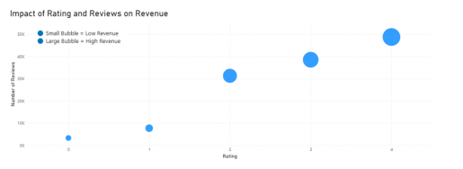

```python
img_path = "/kaggle/input/sportsviz/RatingReviewOnRevenue.png"
img = mpimg.imread(img_path)
plt.imshow(img)
plt.axis('off')
plt.show()
```

Higher-rated products (on the X-axis) attract more reviews (on the Y-axis) and generate more revenue (indicated by larger bubble sizes).

**Strategical Takeaways:**

- If certain products are stuck at low ratings with few reviews, the store could investigate quality issues, marketing gaps, or the need for promotional strategies.
- Encouraging more reviews (e.g., through post-purchase emails or incentives) might help discover issues earlier and boost product visibility.

**Correlation with Store Strategy**

- Products that are well-received (higher ratings) seem to drive significantly more revenue, reinforcing the idea that investing in product quality and customer satisfaction can pay off financially.

## Relationship Between Discount and Revenue

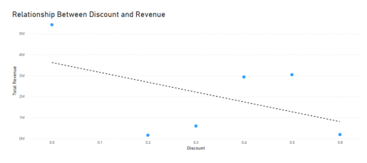

```python
img_path = "/kaggle/input/sportsviz/DiscountVsRevenue.png"
img = mpimg.imread(img_path)
plt.imshow(img)
plt.axis('off')
plt.show()
```

This scatter plot shows the relationship between Discount (x-axis) and Total Revenue (y-axis) with a trend line indicating the general pattern.

**Outliers**

- There’s a notable data point with zero discount but very high revenue (around 5M). This suggests that some products perform exceptionally well even without discounts — possibly premium or highly demanded items.
- In the 0.4 - 0.5 range, the revenue is still relatively high, indicating that discounts in this range may sometimes be effective.

**Strategical Takeaways:**

- Identify high-performing products that don’t require discounts. Highlight these in marketing campaigns to maximize revenue.
- Experiment with moderate discount ranges (e.g., 0.3 - 0.5) for select products, as these show some potential for maintaining revenue.

## Total Revenue by Year

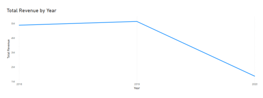

```python
img_path = "/kaggle/input/sportsviz/RevenueByYear.png"
img = mpimg.imread(img_path)
plt.imshow(img)
plt.axis('off')
plt.show()
```

## Number of Products by Gender & Total Revenue and Average Revenue by Gender

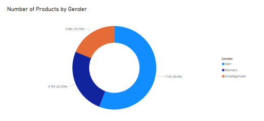

```python
img_path = "/kaggle/input/sportsviz/NumOfProductsByGender.png"
img = mpimg.imread(img_path)
plt.imshow(img)
plt.axis('off')
plt.show()
```

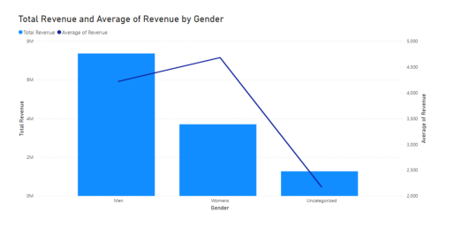

```python
img_path = "/kaggle/input/sportsviz/RevenueByGender.png"
img = mpimg.imread(img_path)
plt.imshow(img)
plt.axis('off')
plt.show()
```

**Strategical Takeaways:**

- Optimize inventory allocation by expanding women’s product line. Since women’s products have a higher average revenue, consider adding more SKUs in this category.
- Targeted Marketing & Bundling
  - Men’s: Maintain or slightly optimize, as it already contributes the majority of revenue.
  - Women’s: Promote the higher-value products with targeted campaigns (e.g., loyalty programs, social media ads).
  - Bundle men’s and women’s items to cross-sell (e.g., “his & hers” sports gear). Refine Product Categorization
- Investigate the Uncategorized items. Are they truly unisex, or is it missing data? Proper labeling might allow more focused marketing strategies and inventory decisions.

## Brand Performance

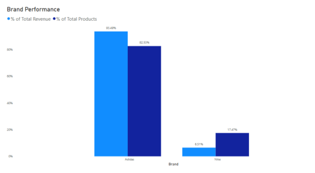

```python
img_path = "/kaggle/input/sportsviz/BrandRevenuePerformance.png"
img = mpimg.imread(img_path)
plt.imshow(img)
plt.axis('off')
plt.show()
```

Nike accounts for 17.47% of products, generating 6.51% of total revenue. Nike’s revenue share is also lower than its product share, suggesting that many Nike items might not be generating enough sales or are not marketed effectively.

**Strategic Takeaways:**

- Since Adidas dominates inventory, identify and phase out underperforming SKUs that might be dragging down average revenue.
- Focus on best-selling Adidas lines with stronger margins or brand loyalty.
- Nike’s low revenue-to-product ratio indicates a potential marketing gap or product mismatch. Enhance marketing campaigns around Nike products (e.g., targeted ads, bundling, or influencer partnerships).
- Consider reducing or repositioning underperforming Nike items to improve overall brand profitability.
- Evaluate Pricing Strategy
  - If Adidas items are priced too low, the store could test slight price increases on popular SKUs.
  - If Nike items are not resonating at current price points, consider promotions or repositioning to encourage sales without oversaturating discounts.

## Discount by Brand

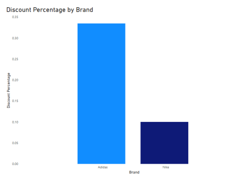

```python
img_path = "/kaggle/input/sportsviz/DiscountByBrand.png"
img = mpimg.imread(img_path)
plt.imshow(img)
plt.axis('off')
plt.show()
```

The chart shows that Adidas applies a significantly higher average discount compared to Nike. Given Adidas already has the largest share of inventory (~82.6%), a high discount strategy may be designed to clear stock or stay competitive.

Nike’s discount percentage is noticeably lower, which might align with Nike’s premium brand positioning or a strategy focusing on maintaining higher margins. This could also contribute to Nike’s lower revenue share, as fewer discounts might result in fewer impulse or price-sensitive purchases.

**Strategic Takeaways:**

- Since Adidas is heavily discounted, it may be cannibalizing its own profit margin. Identify which Adidas products genuinely need discounts (slow movers, older stock) and reduce or remove blanket discounts on well-performing lines.
- Consider implementing targeted promotions for Adidas items (e.g., email campaigns for older inventory) rather than a broad, high discount rate across the entire brand. This approach can maintain margin on popular Adidas products while still clearing less desirable stock.
- Nike’s lower discount might be a strategic choice to maintain a premium image, but the store could explore small, strategic discounts on certain Nike products to boost sales volume without devaluing the brand.

## Revenue by Product and Brand

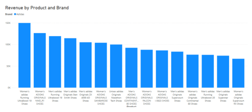

```python
img_path = "/kaggle/input/sportsviz/RevenueByProductandBrand.png"
img = mpimg.imread(img_path)
plt.imshow(img)
plt.axis('off')
plt.show()
```

The top performing 15 products are all from Adidas

## Average Rating by Brand

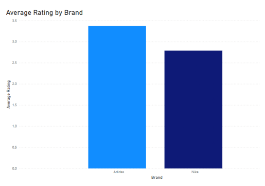

```python
img_path = "/kaggle/input/sportsviz/AvgRatingByBrand.png"
img = mpimg.imread(img_path)
plt.imshow(img)
plt.axis('off')
plt.show()
```

Nike’s lower rating suggests potential issues:

- Product quality concerns
- Pricing issues
- Mismatch with customer expectations

Both ratings are below 4.0 (which is generally considered a good benchmark for customer satisfaction). Even though Adidas leads, there is room for improvement for both brands to increase customer satisfaction.

**Strategic Takeaways**:

- Introduce customer satisfaction surveys to gather detailed feedback.
- Adjust pricing, product selection, or customer service based on feedback.
- Identify if specific product categories (e.g., shoes, apparel) are driving the lower rating.
- Leverage Adidas' Higher Rating to Boost Sales by offering bundle deals

**Strategic Takeaways:**

- Identify Adidas products in the 0–2 star range. Investigate common complaints (quality, sizing, style) and either improve or discontinue these items. By removing consistently underperforming products, Adidas’s average rating should improve.
- For both brands, but especially Adidas, promote the 4-star items more aggressively. Use marketing campaigns or site placement to showcase well-reviewed items, encouraging customers to associate Adidas with quality.
- Implement or improve post-purchase review incentives. More feedback helps identify problem SKUs earlier and refine the product line.
- For Adidas, capturing feedback on mid-rated products (3 stars) can lead to quick improvements (design tweaks, better materials).